# Final Project for PPG PartII : Regression-iiA

Hua Ji

4/22/2022

## Load packages

The `tidyverse` and `caret` packages are loaded below.

```r
library(tidyverse)
library(caret)
```

## Read and prepare data

```r
df_all <- readr::read_csv("final_project_train.csv", col_names = TRUE)
df_all %>%glimpse()
```

```
## Rows: 677
## Columns: 38
## $ rowid    <dbl> 1, 3, 4, 5, 8, 9, 11, 14, 15, 16, 17, 18, 19, 22, 24, 25, 27,…
## $ region   <chr> "XX", "XX", "XX", "XX", "XX", "XX", "XX", "XX", "XX", "XX", "…
## $ customer <chr> "B", "B", "B", "B", "B", "B", "B", "B", "B", "B", "B", "B", "…
## $ xb_01    <dbl> 4.000000, 1.000000, 2.000000, 2.520000, 2.548387, 3.071429, 3…
## $ xb_02    <dbl> 4, 1, 2, 11, 6, 6, 10, 12, 9, 10, 8, 10, 10, 8, 6, 10, 13, 10…
## $ xb_03    <dbl> 4, 1, 2, -6, -1, 1, -4, -4, -2, -4, -2, -2, -2, -4, 1, -4, -3…
## $ xn_01    <dbl> 3.0000000, 2.0000000, 2.0000000, 1.5333333, 0.8387097, 1.8571…
## $ xn_02    <dbl> 3, 2, 4, 9, 3, 8, 6, 10, 10, 4, 6, 8, 9, 5, 7, 12, 12, 6, 6, …
## $ xn_03    <dbl> 3, 2, 0, -3, -4, -2, -5, -6, -3, -5, -3, -6, -4, -3, 0, -5, -…
## $ xa_01    <dbl> 12.000000, 3.000000, 9.000000, 7.080000, 6.451613, 6.857143, …
## $ xa_02    <dbl> 12, 3, 9, 29, 17, 18, 24, 27, 20, 19, 15, 24, 24, 15, 14, 26,…
## $ xa_03    <dbl> 12, 3, 9, -7, -2, 2, -9, -5, -3, -3, -1, 1, -2, -3, 3, -4, -5…
## $ xb_04    <dbl> 1.3333333, 1.0000000, 1.0000000, 0.8950476, 1.2247312, 1.1857…
```

[output cut: 25 more lines]

## Added log-transformed response

```r
log_all<-df_all %>%mutate(logresponse =log(response))%>%select(!c(rowid, response,outcome))
log_all%>%glimpse()
```

```
## Rows: 677
## Columns: 36
## $ region      <chr> "XX", "XX", "XX", "XX", "XX", "XX", "XX", "XX", "XX", "XX"…
## $ customer    <chr> "B", "B", "B", "B", "B", "B", "B", "B", "B", "B", "B", "B"…
## $ xb_01       <dbl> 4.000000, 1.000000, 2.000000, 2.520000, 2.548387, 3.071429…
## $ xb_02       <dbl> 4, 1, 2, 11, 6, 6, 10, 12, 9, 10, 8, 10, 10, 8, 6, 10, 13,…
## $ xb_03       <dbl> 4, 1, 2, -6, -1, 1, -4, -4, -2, -4, -2, -2, -2, -4, 1, -4,…
## $ xn_01       <dbl> 3.0000000, 2.0000000, 2.0000000, 1.5333333, 0.8387097, 1.8…
## $ xn_02       <dbl> 3, 2, 4, 9, 3, 8, 6, 10, 10, 4, 6, 8, 9, 5, 7, 12, 12, 6, …
## $ xn_03       <dbl> 3, 2, 0, -3, -4, -2, -5, -6, -3, -5, -3, -6, -4, -3, 0, -5…
## $ xa_01       <dbl> 12.000000, 3.000000, 9.000000, 7.080000, 6.451613, 6.85714…
## $ xa_02       <dbl> 12, 3, 9, 29, 17, 18, 24, 27, 20, 19, 15, 24, 24, 15, 14, …
## $ xa_03       <dbl> 12, 3, 9, -7, -2, 2, -9, -5, -3, -3, -1, 1, -2, -3, 3, -4,…
## $ xb_04       <dbl> 1.3333333, 1.0000000, 1.0000000, 0.8950476, 1.2247312, 1.1…
## $ xb_05       <dbl> 1.3333333, 1.0000000, 1.0000000, -2.0000000, -0.5000000, 0…
```

[output cut: 23 more lines]

###Models

##Categorical variables only – linear additive

```r
mod1<-lm(logresponse~region+customer,data =log_all)
mod1%>%summary()
```

```
##
## Call:
## lm(formula = logresponse ~ region + customer, data = log_all)
##
## Residuals:
##      Min       1Q   Median       3Q      Max
## -1.32970 -0.31319 -0.00337  0.30227  1.99231
##
## Coefficients:
##               Estimate Std. Error t value Pr(>|t|)
## (Intercept)    0.98704    0.09681  10.195  < 2e-16 ***
## regionYY       0.30755    0.05369   5.728 1.54e-08 ***
## regionZZ      -0.27549    0.07110  -3.875 0.000117 ***
## customerB     -0.17728    0.11613  -1.527 0.127350
## customerD     -0.04539    0.12781  -0.355 0.722633
## customerE     -0.17532    0.12539  -1.398 0.162518
## customerG     -0.14673    0.08142  -1.802 0.071969 .
## customerK      0.08604    0.10280   0.837 0.402904
## customerM     -0.16753    0.08753  -1.914 0.056065 .
## customerOther -0.15480    0.09271  -1.670 0.095448 .
## customerQ     -0.33603    0.12855  -2.614 0.009150 **
## ---
## Signif. codes:  0 '***' 0.001 '**' 0.01 '*' 0.05 '.' 0.1 ' ' 1
##
## Residual standard error: 0.4873 on 666 degrees of freedom
## Multiple R-squared:  0.1822, Adjusted R-squared:   0.17
## F-statistic: 14.84 on 10 and 666 DF,  p-value: < 2.2e-16
```

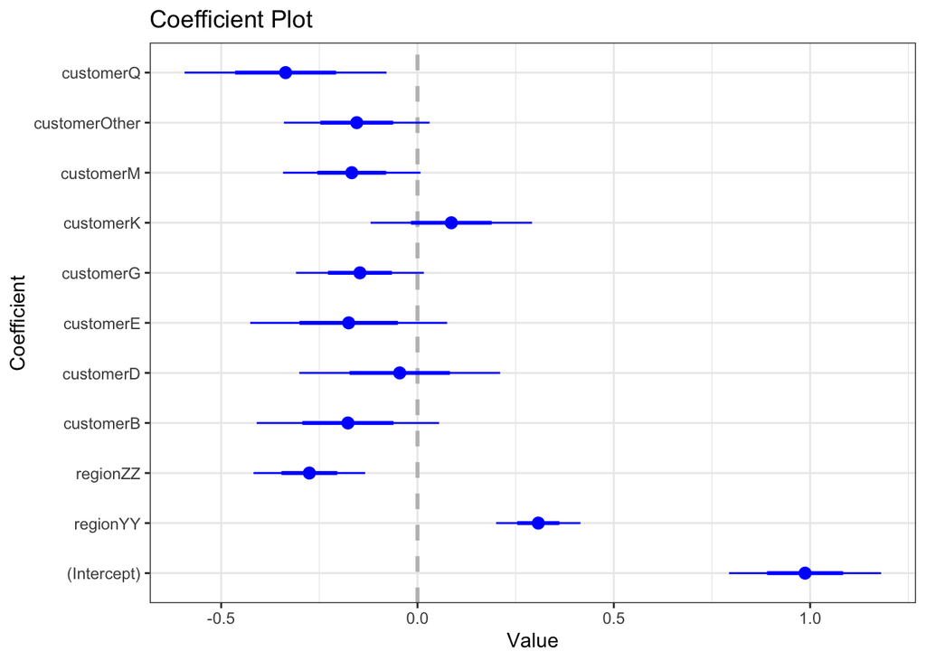

```r
mod1 %>%
  coefplot::coefplot() +
  theme_bw() +
  theme(legend.position = 'none')
```

##Continuous variables only – linear additive

```r
mod2<-lm(logresponse~.-region-customer,data =log_all)
summary(mod2)
```

```
##
## Call:
## lm(formula = logresponse ~ . - region - customer, data = log_all)
##
## Residuals:
##     Min      1Q  Median      3Q     Max
## -1.1981 -0.2279 -0.0121  0.2308  1.7563
##
## Coefficients:
##               Estimate Std. Error t value Pr(>|t|)
## (Intercept) -0.3065731  0.0832408  -3.683 0.000250 ***
## xb_01        0.0451928  0.0399721   1.131 0.258642
## xb_02        0.0197021  0.0167751   1.174 0.240634
## xb_03        0.0067157  0.0253421   0.265 0.791094
## xn_01        0.0436725  0.0380814   1.147 0.251883
## xn_02        0.0070652  0.0176705   0.400 0.689412
## xn_03       -0.0372646  0.0215715  -1.727 0.084559 .
## xa_01       -0.0419267  0.0202378  -2.072 0.038691 *
## xa_02        0.0226529  0.0082193   2.756 0.006016 **
## xa_03        0.0040960  0.0130010   0.315 0.752823
## xb_04       -0.4689904  0.1300432  -3.606 0.000335 ***
## xb_05        0.0408992  0.0609840   0.671 0.502682
## xb_06        0.0151322  0.0324939   0.466 0.641592
## xb_07        0.1664855  0.0505356   3.294 0.001040 **
## xb_08        0.1289615  0.0527916   2.443 0.014840 *
## xn_04        0.1442231  0.1163268   1.240 0.215498
## xn_05        0.1644335  0.0497648   3.304 0.001005 **
## xn_06        0.0536260  0.0316213   1.696 0.090392 .
## xn_07       -0.0286324  0.0475703  -0.602 0.547454
## xn_08       -0.1079277  0.0451179  -2.392 0.017037 *
## xa_04        0.0200902  0.0636645   0.316 0.752436
## xa_05        0.0330188  0.0263357   1.254 0.210383
## xa_06       -0.0085964  0.0130347  -0.660 0.509809
## xa_07        0.0255978  0.0282339   0.907 0.364940
## xa_08       -0.0136748  0.0286572  -0.477 0.633393
## xw_01        0.0139666  0.0033112   4.218 2.82e-05 ***
## xw_02       -0.0007236  0.0017305  -0.418 0.675994
## xw_03       -0.0022127  0.0019083  -1.160 0.246682
## xs_01       -0.1063306  0.2914305  -0.365 0.715338
## xs_02       -0.2629219  0.1628957  -1.614 0.107007
## xs_03       -0.0161401  0.1315986  -0.123 0.902425
## xs_04        0.2308584  0.4448027   0.519 0.603930
## xs_05       -0.0926908  0.3159142  -0.293 0.769307
## xs_06       -0.0286369  0.1745249  -0.164 0.869716
## ---
## Signif. codes:  0 '***' 0.001 '**' 0.01 '*' 0.05 '.' 0.1 ' ' 1
##
## Residual standard error: 0.371 on 643 degrees of freedom
## Multiple R-squared:  0.5424, Adjusted R-squared:  0.5189
## F-statistic:  23.1 on 33 and 643 DF,  p-value: < 2.2e-16
```

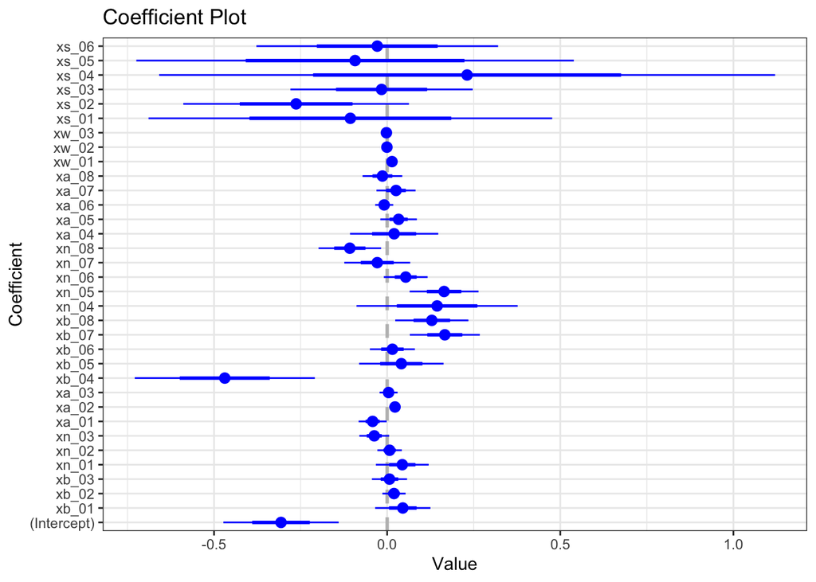

```r
mod2 %>%
  coefplot::coefplot() +
  theme_bw() +
  theme(legend.position = 'none')
```

##All categorical and continuous variables – linear additive

```r
mod3 <-lm(logresponse~.,data =log_all)
summary(mod3)
```

```
##
## Call:
## lm(formula = logresponse ~ ., data = log_all)
##
## Residuals:
##      Min       1Q   Median       3Q      Max
## -1.09325 -0.19510 -0.00288  0.19697  1.55830
##
## Coefficients:
##                 Estimate Std. Error t value Pr(>|t|)
## (Intercept)   -0.1669985  0.0972122  -1.718 0.086308 .
## regionYY       0.2773254  0.0368271   7.530 1.75e-13 ***
## regionZZ      -0.2237414  0.0482942  -4.633 4.38e-06 ***
## customerB     -0.1268227  0.0792864  -1.600 0.110197
## customerD     -0.0680785  0.0861122  -0.791 0.429486
## customerE     -0.0987833  0.0870483  -1.135 0.256884
## customerG     -0.1083341  0.0540328  -2.005 0.045392 *
## customerK      0.2258940  0.0694501   3.253 0.001204 **
## customerM     -0.1961907  0.0577286  -3.398 0.000720 ***
## customerOther -0.0505227  0.0620174  -0.815 0.415577
## customerQ     -0.2305592  0.0859905  -2.681 0.007527 **
## xb_01          0.0081990  0.0345362   0.237 0.812420
## xb_02          0.0218299  0.0146159   1.494 0.135787
## xb_03          0.0262128  0.0218907   1.197 0.231583
## xn_01         -0.0013212  0.0328519  -0.040 0.967933
## xn_02          0.0170421  0.0152156   1.120 0.263121
## xn_03         -0.0032394  0.0186148  -0.174 0.861904
## xa_01         -0.0187389  0.0173931  -1.077 0.281722
## xa_02          0.0146374  0.0070563   2.074 0.038448 *
## xa_03         -0.0001943  0.0111639  -0.017 0.986122
## xb_04         -0.3466263  0.1126611  -3.077 0.002183 **
## xb_05          0.0163756  0.0527677   0.310 0.756410
## xb_06         -0.0019072  0.0278762  -0.068 0.945476
## xb_07          0.1577135  0.0435215   3.624 0.000314 ***
## xb_08          0.1109006  0.0454160   2.442 0.014884 *
## xn_04          0.2100798  0.0999153   2.103 0.035897 *
## xn_05          0.0872328  0.0429097   2.033 0.042475 *
## xn_06          0.0235933  0.0272332   0.866 0.386631
## xn_07         -0.0086688  0.0410514  -0.211 0.832824
## xn_08         -0.0951218  0.0386279  -2.463 0.014062 *
## xa_04          0.0405829  0.0548735   0.740 0.459834
## xa_05          0.0126008  0.0225470   0.559 0.576451
## xa_06         -0.0100157  0.0111866  -0.895 0.370952
## xa_07          0.0199217  0.0244745   0.814 0.415964
## xa_08         -0.0144509  0.0246026  -0.587 0.557162
## xw_01          0.0134239  0.0029352   4.573 5.78e-06 ***
## xw_02          0.0002496  0.0015209   0.164 0.869696
## xw_03         -0.0028942  0.0016789  -1.724 0.085217 .
## xs_01         -0.2029905  0.2489528  -0.815 0.415163
## xs_02         -0.1794775  0.1397968  -1.284 0.199666
## xs_03         -0.0242163  0.1130385  -0.214 0.830436
## xs_04         -0.1352323  0.3836254  -0.353 0.724572
## xs_05          0.1247916  0.2716155   0.459 0.646074
## xs_06          0.0908242  0.1509106   0.602 0.547496
## ---
## Signif. codes:  0 '***' 0.001 '**' 0.01 '*' 0.05 '.' 0.1 ' ' 1
##
## Residual standard error: 0.3161 on 633 degrees of freedom
## Multiple R-squared:  0.673,  Adjusted R-squared:  0.6508
## F-statistic: 30.29 on 43 and 633 DF,  p-value: < 2.2e-16
```

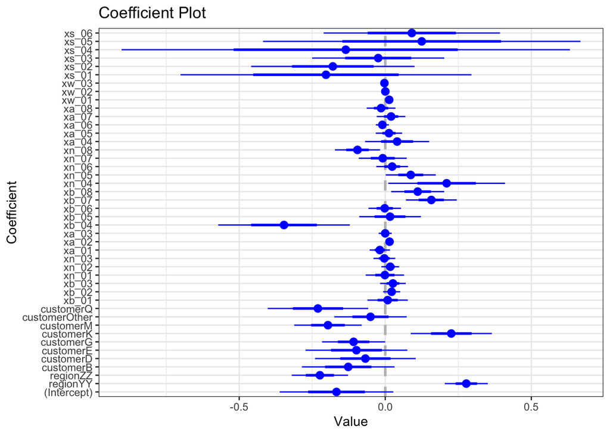

```r
mod3 %>%
  coefplot::coefplot() +
  theme_bw() +
  theme(legend.position = 'none')
```

##Interact region with continuous inputs, do not include customer

```r
mod4<- lm(logresponse ~ region * (.-region), data = log_all %>% select(!c( "customer" )))
summary(mod4)
```

```
##
## Call:
## lm(formula = logresponse ~ region * (. - region), data = log_all %>%
##     select(!c("customer")))
##
## Residuals:
##      Min       1Q   Median       3Q      Max
## -1.14449 -0.17857 -0.01307  0.16378  1.60998
##
## Coefficients:
##                 Estimate Std. Error t value Pr(>|t|)
## (Intercept)    -0.355967   0.197435  -1.803   0.0719 .
## regionYY       -0.075308   0.256068  -0.294   0.7688
## regionZZ        0.141771   0.216660   0.654   0.5132
## xb_01          -0.008468   0.072037  -0.118   0.9065
## xb_02           0.046034   0.023352   1.971   0.0492 *
## xb_03           0.025466   0.044856   0.568   0.5704
## xn_01          -0.029279   0.062135  -0.471   0.6377
## xn_02           0.004533   0.023365   0.194   0.8462
## xn_03           0.011483   0.034735   0.331   0.7411
## xa_01          -0.028919   0.036691  -0.788   0.4309
## xa_02           0.008184   0.012230   0.669   0.5036
## xa_03           0.019621   0.021563   0.910   0.3632
## xb_04          -0.484684   0.283643  -1.709   0.0880 .
## xb_05          -0.031779   0.091824  -0.346   0.7294
## xb_06          -0.009802   0.055831  -0.176   0.8607
## xb_07           0.229452   0.115389   1.989   0.0472 *
## xb_08           0.148110   0.117211   1.264   0.2069
## xn_04           0.576168   0.271881   2.119   0.0345 *
## xn_05           0.019442   0.072495   0.268   0.7887
## xn_06          -0.015787   0.058433  -0.270   0.7871
## xn_07          -0.064442   0.112491  -0.573   0.5670
## xn_08          -0.191051   0.118313  -1.615   0.1069
## xa_04          -0.077385   0.174937  -0.442   0.6584
## xa_05           0.007842   0.040371   0.194   0.8460
## xa_06           0.009596   0.021554   0.445   0.6563
## xa_07           0.099755   0.079194   1.260   0.2083
## xa_08          -0.021274   0.087164  -0.244   0.8073
## xw_01           0.005230   0.004805   1.088   0.2768
## xw_02           0.002731   0.002747   0.994   0.3206
```

[output cut: 64 more lines]

```
## regionZZ:xs_02 -0.057637   0.457752  -0.126   0.8998
## regionYY:xs_03  0.362191   0.258931   1.399   0.1624
## regionZZ:xs_03  0.220526   0.387927   0.568   0.5699
## regionYY:xs_04  0.374168   0.955222   0.392   0.6954
## regionZZ:xs_04  0.608575   1.232822   0.494   0.6217
## regionYY:xs_05  0.099429   0.710865   0.140   0.8888
## regionZZ:xs_05 -0.282546   0.804980  -0.351   0.7257
## regionYY:xs_06 -0.243310   0.336867  -0.722   0.4704
## regionZZ:xs_06 -0.374352   0.515073  -0.727   0.4676
## ---
## Signif. codes:  0 '***' 0.001 '**' 0.01 '*' 0.05 '.' 0.1 ' ' 1
##
## Residual standard error: 0.3029 on 575 degrees of freedom
## Multiple R-squared:  0.7273, Adjusted R-squared:  0.6794
## F-statistic: 15.18 on 101 and 575 DF,  p-value: < 2.2e-16
```

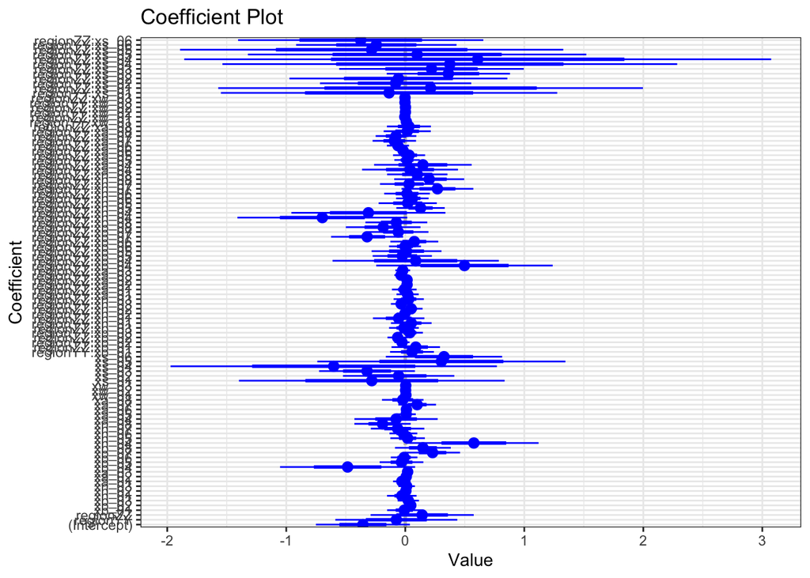

```r
mod4 %>%
  coefplot::coefplot() +
  theme_bw() +
  theme(legend.position = 'none')
```

##Interact customer with continuous inputs, do not include region

```r
mod5<- lm(logresponse ~ customer * (.-customer), data = log_all %>% select(!c( "region")))
summary(mod5)
```

```
##
## Call:
## lm(formula = logresponse ~ customer * (. - customer), data = log_all %>%
##     select(!c("region")))
##
## Residuals:
##     Min      1Q  Median      3Q     Max
## -0.8851 -0.1095  0.0000  0.1113  1.3645
##
## Coefficients: (6 not defined because of singularities)
##                       Estimate Std. Error t value Pr(>|t|)
## (Intercept)          -0.224852   0.233650  -0.962  0.33649
## customerB             0.082908   0.945089   0.088  0.93014
## customerD            -0.106606   2.924609  -0.036  0.97094
## customerE            -2.682507   4.852335  -0.553  0.58071
## customerG             0.131714   0.293648   0.449  0.65402
## customerK            -0.786969   0.893974  -0.880  0.37926
## customerM             0.003022   0.359515   0.008  0.99330
## customerOther        -0.391762   0.269936  -1.451  0.14752
## customerQ             0.682093   0.752653   0.906  0.36538
## xb_01                 2.550524   7.976465   0.320  0.74933
## xb_02                -1.014996   4.365304  -0.233  0.81626
## xb_03                -1.526995   3.669596  -0.416  0.67756
## xn_01                 2.307220   6.068048   0.380  0.70399
## xn_02                -0.952186   3.126937  -0.305  0.76091
## xn_03                -1.273149   2.996169  -0.425  0.67113
## xa_01                -0.947653   2.814871  -0.337  0.73656
## xa_02                 0.412311   1.422228   0.290  0.77205
## xa_03                 0.544269   1.442359   0.377  0.70613
## xb_04                10.522349  38.076092   0.276  0.78243
## xb_05                -5.043867  19.665086  -0.256  0.79771
## xb_06                -5.601013  18.448319  -0.304  0.76160
## xb_07                 0.135850   0.113559   1.196  0.23233
## xb_08                 0.023890   0.148137   0.161  0.87197
## xn_04                 0.278640  21.374105   0.013  0.98961
## xn_05                -0.496485  10.154782  -0.049  0.96103
## xn_06                 0.100649  11.223690   0.009  0.99285
## xn_07                -0.000752   0.090600  -0.008  0.99338
## xn_08                 0.018440   0.106121   0.174  0.86215
## xa_04                -3.019013   5.373675  -0.562  0.57458
```

[output cut: 268 more lines]

```
## customerQ:xs_05             NA         NA      NA       NA
## customerB:xs_06      -2.123461   3.766471  -0.564  0.57324
## customerD:xs_06             NA         NA      NA       NA
## customerE:xs_06      -3.685410   5.290375  -0.697  0.48647
## customerG:xs_06      -2.109835   3.813133  -0.553  0.58038
## customerK:xs_06       0.624699   4.853960   0.129  0.89766
## customerM:xs_06      -4.097504   3.907510  -1.049  0.29502
## customerOther:xs_06  -1.489910   3.743249  -0.398  0.69084
## customerQ:xs_06             NA         NA      NA       NA
## ---
## Signif. codes:  0 '***' 0.001 '**' 0.01 '*' 0.05 '.' 0.1 ' ' 1
##
## Residual standard error: 0.3029 on 377 degrees of freedom
## Multiple R-squared:  0.8211, Adjusted R-squared:  0.6793
## F-statistic: 5.788 on 299 and 377 DF,  p-value: < 2.2e-16
```

[figure not shown]

```r
mod5 %>%
  coefplot::coefplot() +
  theme_bw() +
  theme(legend.position = 'none')
```

##All pairwise interactions of continuous inputs, do not include categorical inputs

```r
mod6<- lm(logresponse ~ (.)^2, data = log_all %>% select(!c( "customer","region")))
summary(mod6)
```

```
##
## Call:
## lm(formula = logresponse ~ (.)^2, data = log_all %>% select(!c("customer",
##     "region")))
##
## Residuals:
##      Min       1Q   Median       3Q      Max
## -0.68357 -0.05242 -0.00157  0.05425  1.10310
##
## Coefficients:
##               Estimate Std. Error t value Pr(>|t|)
## (Intercept) -5.836e-01  4.596e-01  -1.270   0.2067
## xb_01       -8.156e-01  2.020e+00  -0.404   0.6871
## xb_02        1.600e-01  1.097e+00   0.146   0.8843
## xb_03        5.298e-01  1.219e+00   0.435   0.6645
## xn_01        1.308e+00  3.874e+00   0.338   0.7362
## xn_02       -1.252e+00  1.795e+00  -0.698   0.4868
## xn_03       -3.235e-01  2.238e+00  -0.145   0.8853
## xa_01        2.067e-01  9.570e-01   0.216   0.8293
## xa_02       -5.563e-03  5.613e-01  -0.010   0.9921
## xa_03       -1.661e-01  4.927e-01  -0.337   0.7366
## xb_04        7.618e+00  6.763e+00   1.126   0.2623
## xb_05       -3.013e+00  3.944e+00  -0.764   0.4465
## xb_06       -2.811e+00  3.311e+00  -0.849   0.3978
## xb_07       -7.282e-01  5.655e-01  -1.288   0.2004
## xb_08       -1.098e+00  6.037e-01  -1.819   0.0716 .
## xn_04       -4.869e+00  8.430e+00  -0.578   0.5647
## xn_05        9.435e-01  5.253e+00   0.180   0.8578
## xn_06        3.054e+00  3.424e+00   0.892   0.3742
## xn_07        8.354e-01  5.888e-01   1.419   0.1587
## xn_08        4.556e-01  5.114e-01   0.891   0.3749
## xa_04        5.751e-01  2.909e+00   0.198   0.8436
## xa_05       -3.620e-02  1.811e+00  -0.020   0.9841
## xa_06       -1.044e-01  1.381e+00  -0.076   0.9399
## xa_07        2.959e-02  3.624e-01   0.082   0.9351
## xa_08       -1.175e-01  3.349e-01  -0.351   0.7263
## xw_01        5.026e-02  1.660e-01   0.303   0.7627
## xw_02       -4.402e-03  8.870e-02  -0.050   0.9605
## xw_03       -3.768e-02  8.338e-02  -0.452   0.6522
## xs_01       -3.956e+00  2.021e+01  -0.196   0.8451
```

[output cut: 524 more lines]

```
## xs_02:xs_04 -2.336e+01  2.295e+01  -1.018   0.3110
## xs_02:xs_05  3.286e-01  1.598e+01   0.021   0.9836
## xs_02:xs_06  5.544e+00  6.283e+00   0.882   0.3794
## xs_03:xs_04 -5.027e-02  2.736e+01  -0.002   0.9985
## xs_03:xs_05 -2.422e+00  2.098e+01  -0.115   0.9083
## xs_03:xs_06  1.013e+00  5.955e+00   0.170   0.8653
## xs_04:xs_05  1.810e+01  1.516e+01   1.194   0.2348
## xs_04:xs_06 -2.382e+00  6.896e+00  -0.345   0.7305
## xs_05:xs_06 -1.343e+01  1.425e+01  -0.943   0.3478
## ---
## Signif. codes:  0 '***' 0.001 '**' 0.01 '*' 0.05 '.' 0.1 ' ' 1
##
## Residual standard error: 0.3566 on 115 degrees of freedom
## Multiple R-squared:  0.9244, Adjusted R-squared:  0.5555
## F-statistic: 2.506 on 561 and 115 DF,  p-value: 6.528e-09
```

[figure not shown]

```r
mod6 %>%
  coefplot::coefplot() +
  theme_bw() +
  theme(legend.position = 'none')
```

##Natural splines interaction

```r
mod7<- lm(logresponse ~ splines::ns(xb_04,5)*splines::ns(xn_05,5), data = log_all)
summary(mod7)
```

```
##
## Call:
## lm(formula = logresponse ~ splines::ns(xb_04, 5) * splines::ns(xn_05,
##     5), data = log_all)
##
## Residuals:
##      Min       1Q   Median       3Q      Max
## -1.23874 -0.36444 -0.01608  0.32740  1.98074
##
## Coefficients:
##                                                Estimate Std. Error t value
## (Intercept)                                     -3.0389    14.3814  -0.211
## splines::ns(xb_04, 5)1                           2.7656    14.0724   0.197
## splines::ns(xb_04, 5)2                           4.6288    14.6788   0.315
## splines::ns(xb_04, 5)3                         -13.2600    16.0327  -0.827
## splines::ns(xb_04, 5)4                          66.6691    76.1909   0.875
## splines::ns(xb_04, 5)5                         125.7781   140.4302   0.896
## splines::ns(xn_05, 5)1                           7.5126    13.6223   0.551
## splines::ns(xn_05, 5)2                           1.8526    14.8344   0.125
## splines::ns(xn_05, 5)3                           3.7732     9.3762   0.402
## splines::ns(xn_05, 5)4                          20.9535    37.2263   0.563
## splines::ns(xn_05, 5)5                          37.2309    43.3292   0.859
## splines::ns(xb_04, 5)1:splines::ns(xn_05, 5)1   -6.5462    13.3261  -0.491
## splines::ns(xb_04, 5)2:splines::ns(xn_05, 5)1   -8.0774    13.9184  -0.580
## splines::ns(xb_04, 5)3:splines::ns(xn_05, 5)1    9.9312    15.7537   0.630
## splines::ns(xb_04, 5)4:splines::ns(xn_05, 5)1  -73.6255    75.0544  -0.981
## splines::ns(xb_04, 5)5:splines::ns(xn_05, 5)1 -125.4472   139.2707  -0.901
## splines::ns(xb_04, 5)1:splines::ns(xn_05, 5)2   -0.7430    14.5216  -0.051
## splines::ns(xb_04, 5)2:splines::ns(xn_05, 5)2   -2.6135    15.1323  -0.173
## splines::ns(xb_04, 5)3:splines::ns(xn_05, 5)2   14.5451    16.1913   0.898
## splines::ns(xb_04, 5)4:splines::ns(xn_05, 5)2  -64.2734    76.7625  -0.837
## splines::ns(xb_04, 5)5:splines::ns(xn_05, 5)2 -126.5778   140.9113  -0.898
## splines::ns(xb_04, 5)1:splines::ns(xn_05, 5)3   -3.9046     9.1934  -0.425
## splines::ns(xb_04, 5)2:splines::ns(xn_05, 5)3   -4.2248     9.5353  -0.443
## splines::ns(xb_04, 5)3:splines::ns(xn_05, 5)3    5.5819     9.0577   0.616
## splines::ns(xb_04, 5)4:splines::ns(xn_05, 5)3  -30.5873    40.6234  -0.753
## splines::ns(xb_04, 5)5:splines::ns(xn_05, 5)3  -62.7403    71.3018  -0.880
## splines::ns(xb_04, 5)1:splines::ns(xn_05, 5)4  -18.0914    36.4802  -0.496
## splines::ns(xb_04, 5)2:splines::ns(xn_05, 5)4  -21.7561    37.7929  -0.576
## splines::ns(xb_04, 5)3:splines::ns(xn_05, 5)4   25.7679    33.7980   0.762
```

[output cut: 33 more lines]

```
## splines::ns(xb_04, 5)5:splines::ns(xn_05, 5)3    0.379
## splines::ns(xb_04, 5)1:splines::ns(xn_05, 5)4    0.620
## splines::ns(xb_04, 5)2:splines::ns(xn_05, 5)4    0.565
## splines::ns(xb_04, 5)3:splines::ns(xn_05, 5)4    0.446
## splines::ns(xb_04, 5)4:splines::ns(xn_05, 5)4    0.282
## splines::ns(xb_04, 5)5:splines::ns(xn_05, 5)4    0.362
## splines::ns(xb_04, 5)1:splines::ns(xn_05, 5)5    0.397
## splines::ns(xb_04, 5)2:splines::ns(xn_05, 5)5    0.398
## splines::ns(xb_04, 5)3:splines::ns(xn_05, 5)5    0.967
## splines::ns(xb_04, 5)4:splines::ns(xn_05, 5)5    0.239
## splines::ns(xb_04, 5)5:splines::ns(xn_05, 5)5    0.359
##
## Residual standard error: 0.5099 on 641 degrees of freedom
## Multiple R-squared:  0.1381, Adjusted R-squared:  0.09104
## F-statistic: 2.935 on 35 and 641 DF,  p-value: 7.841e-08
```

## categorical variables and continuous variables interactions

```r
mod8<- lm(logresponse ~(.- region -
    customer)*(region+customer), data = log_all)
summary(mod8)
```

```
##
## Call:
## lm(formula = logresponse ~ (. - region - customer) * (region +
##     customer), data = log_all)
##
## Residuals:
##      Min       1Q   Median       3Q      Max
## -0.62891 -0.08912  0.00000  0.09118  0.85068
##
## Coefficients: (6 not defined because of singularities)
##                       Estimate Std. Error t value Pr(>|t|)
## (Intercept)         -4.376e-01  3.836e-01  -1.141  0.25483
## xb_01               -8.702e-01  7.197e+00  -0.121  0.90384
## xb_02                8.393e-01  3.935e+00   0.213  0.83124
## xb_03               -5.823e-02  3.308e+00  -0.018  0.98597
## xn_01                9.971e-01  5.304e+00   0.188  0.85101
## xn_02               -1.969e-01  2.735e+00  -0.072  0.94264
## xn_03               -6.321e-01  2.618e+00  -0.241  0.80939
## xa_01               -6.363e-01  2.448e+00  -0.260  0.79511
## xa_02                1.599e-01  1.242e+00   0.129  0.89769
## xa_03                5.199e-01  1.251e+00   0.416  0.67788
## xb_04               -4.475e+00  3.443e+01  -0.130  0.89668
## xb_05                2.815e+00  1.777e+01   0.158  0.87425
## xb_06                1.519e+00  1.667e+01   0.091  0.92743
## xb_07               -3.989e-05  2.991e-01   0.000  0.99989
## xb_08                2.176e-02  2.800e-01   0.078  0.93810
## xn_04                8.340e+00  1.911e+01   0.436  0.66286
## xn_05               -4.097e+00  9.070e+00  -0.452  0.65176
## xn_06               -3.964e+00  1.004e+01  -0.395  0.69322
## xn_07               -1.551e-01  2.292e-01  -0.677  0.49905
## xn_08               -3.030e-01  2.094e-01  -1.447  0.14894
## xa_04               -1.966e+00  4.704e+00  -0.418  0.67627
## xa_05                5.227e-01  2.654e+00   0.197  0.84398
## xa_06                1.230e+00  2.083e+00   0.591  0.55527
## xa_07                1.023e-01  1.905e-01   0.537  0.59150
## xa_08                8.109e-02  1.863e-01   0.435  0.66359
## xw_01                4.359e-02  2.493e-01   0.175  0.86133
## xw_02               -1.076e-02  1.331e-01  -0.081  0.93561
## xw_03               -1.562e-02  1.167e-01  -0.134  0.89362
## xs_01               -7.014e-01  3.976e+00  -0.176  0.86009
```

[output cut: 336 more lines]

```
## regionZZ:xs_06      -1.657e-01  1.169e+00  -0.142  0.88738
## customerB:xs_06     -1.952e+00  3.254e+00  -0.600  0.54901
## customerD:xs_06             NA         NA      NA       NA
## customerE:xs_06     -2.010e+00  4.705e+00  -0.427  0.66953
## customerG:xs_06     -8.913e-01  3.430e+00  -0.260  0.79514
## customerK:xs_06      1.039e+00  4.334e+00   0.240  0.81073
## customerM:xs_06     -3.683e+00  3.559e+00  -1.035  0.30146
## customerOther:xs_06 -1.326e+00  3.221e+00  -0.412  0.68091
## customerQ:xs_06             NA         NA      NA       NA
## ---
## Signif. codes:  0 '***' 0.001 '**' 0.01 '*' 0.05 '.' 0.1 ' ' 1
##
## Residual standard error: 0.2603 on 309 degrees of freedom
## Multiple R-squared:  0.8918, Adjusted R-squared:  0.7632
## F-statistic: 6.938 on 367 and 309 DF,  p-value: < 2.2e-16
```

```r
mod9<- lm(logresponse ~ customer*region, data = log_all )
summary(mod9)
```

```
##
## Call:
## lm(formula = logresponse ~ customer * region, data = log_all)
##
## Residuals:
##      Min       1Q   Median       3Q      Max
## -1.33446 -0.30930 -0.00623  0.28143  1.98755
##
## Coefficients: (12 not defined because of singularities)
##                         Estimate Std. Error t value Pr(>|t|)
## (Intercept)             1.262482   0.113958  11.078  < 2e-16 ***
## customerB              -0.446107   0.146797  -3.039 0.002468 **
## customerD              -0.334094   0.163054  -2.049 0.040858 *
## customerE              -0.412173   0.163054  -2.528 0.011708 *
## customerG              -0.746486   0.151785  -4.918 1.10e-06 ***
## customerK               0.086038   0.101430   0.848 0.396606
## customerM              -0.167530   0.086372  -1.940 0.052848 .
## customerOther          -0.341285   0.099919  -3.416 0.000675 ***
## customerQ              -0.527275   0.134953  -3.907 0.000103 ***
## regionYY                0.223349   0.069346   3.221 0.001341 **
## regionZZ               -0.550929   0.093716  -5.879 6.56e-09 ***
## customerB:regionYY      0.070434   0.150400   0.468 0.639718
## customerD:regionYY      0.112500   0.183909   0.612 0.540936
## customerE:regionYY      0.009157   0.176787   0.052 0.958706
## customerG:regionYY            NA         NA      NA       NA
## customerK:regionYY            NA         NA      NA       NA
## customerM:regionYY            NA         NA      NA       NA
## customerOther:regionYY        NA         NA      NA       NA
## customerQ:regionYY            NA         NA      NA       NA
## customerB:regionZZ            NA         NA      NA       NA
## customerD:regionZZ            NA         NA      NA       NA
## customerE:regionZZ            NA         NA      NA       NA
## customerG:regionZZ      0.682641   0.146301   4.666 3.72e-06 ***
## customerK:regionZZ            NA         NA      NA       NA
## customerM:regionZZ            NA         NA      NA       NA
## customerOther:regionZZ        NA         NA      NA       NA
## customerQ:regionZZ            NA         NA      NA       NA
## ---
## Signif. codes:  0 '***' 0.001 '**' 0.01 '*' 0.05 '.' 0.1 ' ' 1
##
## Residual standard error: 0.4808 on 662 degrees of freedom
## Multiple R-squared:  0.2086, Adjusted R-squared:  0.1919
## F-statistic: 12.46 on 14 and 662 DF,  p-value: < 2.2e-16
```

###Model comparison Extract multiple performance metrics for each model.

```r
extract_metrics <- function(mod, mod_name)
{
  broom::glance(mod) %>%
    mutate(model_name = mod_name)
}

model_results <- purrr::map2_dfr(list(mod1, mod2, mod3, mod4,
                                      mod5, mod6, mod7, mod8,
                                      mod9),
                                 sprintf("mod-%02d", 1:9),
                                 extract_metrics)
```

Print the R-squared associated with each model. The models are ordered by decreasing R-squared.

```r
model_results %>%
  select(r.squared, model_name) %>%
  arrange(desc(r.squared))
```

```
## # A tibble: 9 × 2
##   r.squared model_name
##       <dbl> <chr>
## 1     0.924 mod-06
## 2     0.892 mod-08
## 3     0.821 mod-05
## 4     0.727 mod-04
## 5     0.673 mod-03
## 6     0.542 mod-02
## 7     0.209 mod-09
## 8     0.182 mod-01
## 9     0.138 mod-07
```

we can visualize the training set R-squared values.

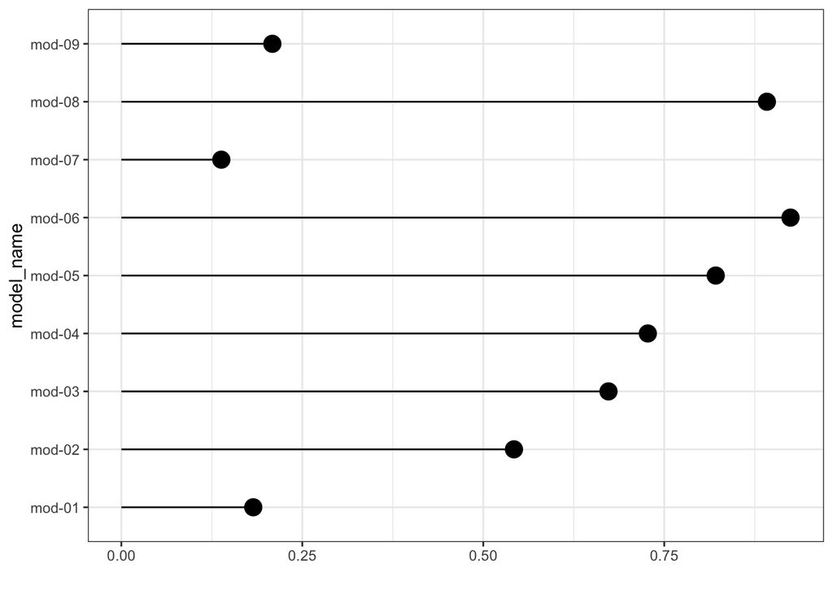

```r
model_results %>%
  ggplot(mapping = aes(x = r.squared, y =model_name )) +
  geom_linerange(mapping = aes(xmin = 0,
                               xmax = r.squared)) +
  geom_point(size = 4.5) +
  labs(x = '') +
  theme_bw()
```

Let’s compare the performance rankings between the 9 models based on AIC and BIC

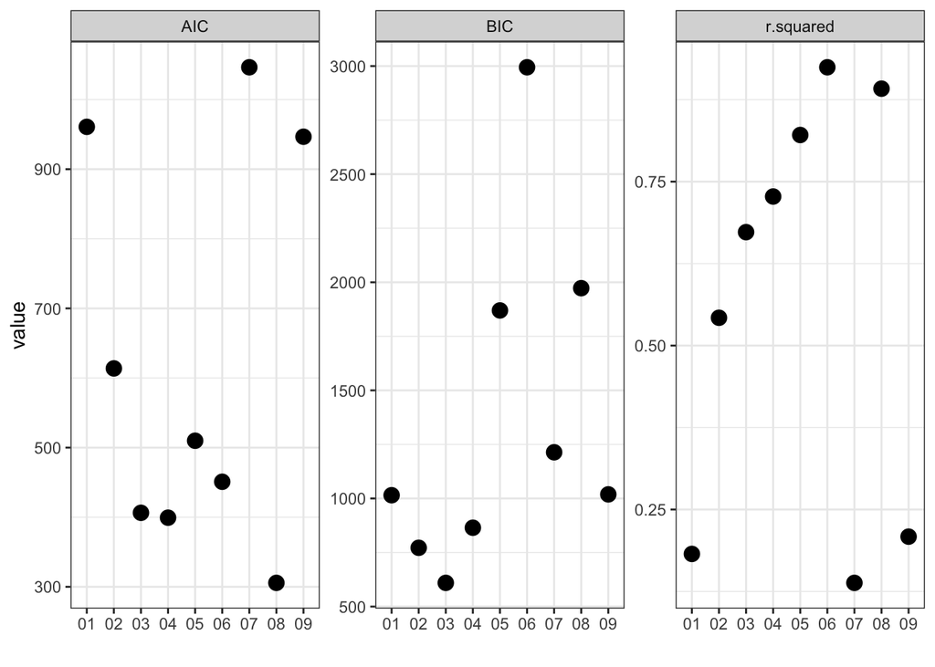

```r
model_results %>%
  select(model_name, r.squared,AIC, BIC) %>%
  pivot_longer(!c("model_name")) %>%
  mutate(model_id = stringr::str_extract(model_name, "\\d+")) %>%
  ggplot(mapping = aes(x = model_id, y = value)) +
  geom_point(size = 3.5) +
  facet_wrap(~name, scales = "free_y") +
  labs(x = '') +
  theme_bw()
```

Based on the AIC,BIC, r.squared results, I choose mod3 as the best model. The top 3 models are mod8,mod3, and mod4.

##Coefficient summaries for mod8.

[figure not shown]

```r
mod8 %>%
  coefplot::coefplot() +
  theme_bw() +
  theme(legend.position = 'none')
```

##Coefficient summaries for mod3.

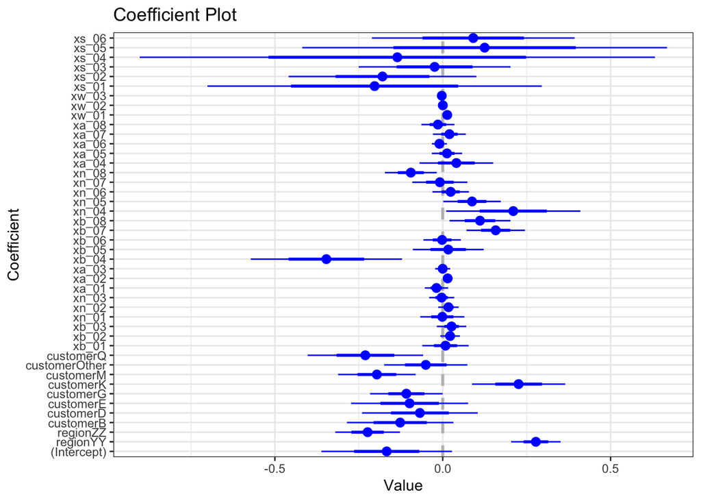

```r
mod3 %>%
  coefplot::coefplot() +
  theme_bw() +
  theme(legend.position = 'none')
```

##Coefficient summaries.

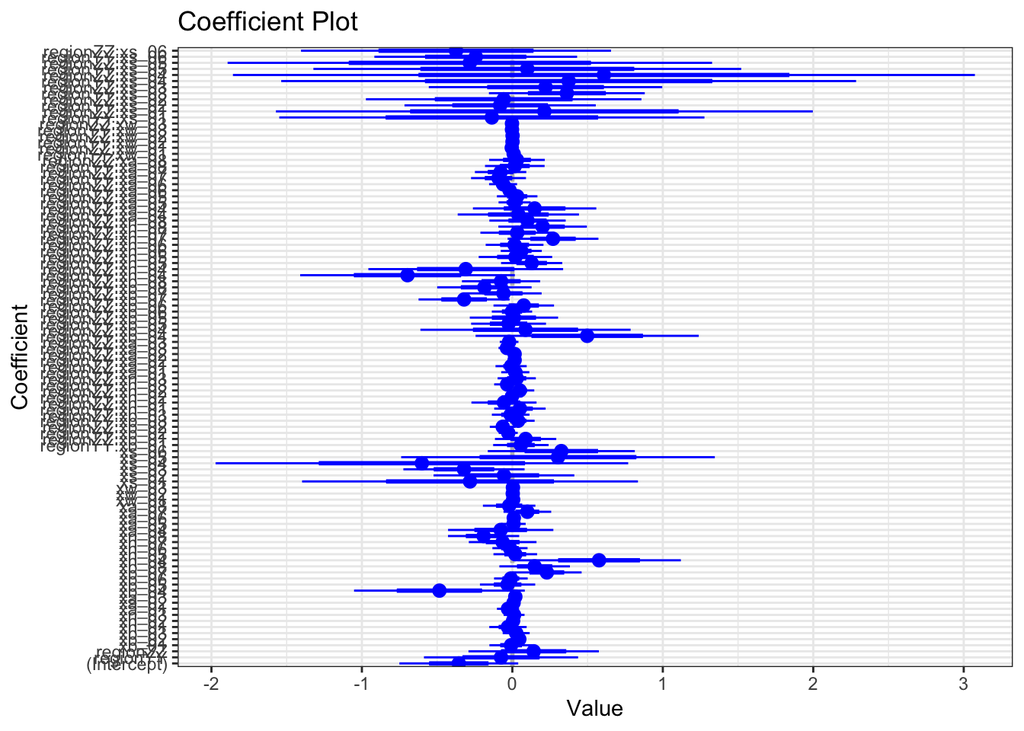

```r
mod4 %>%
  coefplot::coefplot() +
  theme_bw() +
  theme(legend.position = 'none')
```